*Stanislav Borysov [stabo@dtu.dk], DTU Management*

# Advanced Business Analytics

## Refreshing Python and Machine Learning: Part 3 - Pandas

*Based on the notebooks from 42184 Data Science for Mobility E19 / 42577 Introduction to Business Analytics E19*

So, in the previous notebook you learned about Numpy. You probably felt it to be sometimes complicated for routine tasks (e.g. get only data from one of the fields of a file, convert individual fields).

The Pandas module tries to automatize a series of typical tasks that us, Data Scientists, have to do all the time. This doesn't mean that what you learned with Numpy is not useful anymore. In fact, all of that will be precious in many circumstances (e.g. Pandas uses a lot of Numpy features too!).

## 1. Overview: Data frames - a powerful data-structure

The pandas module provides a powerful data-structure called a data frame.

It is similar, but not identical to:

- a table in a relational database,
- an Excel spreadsheet,
- a dataframe in R.

Data frames can be read and written to/from:

- database queries, database tables
- CSV files
- json files

Beware that data frames are memory resident!

## Importing pandas

The pandas module is usually imported with the alias pd.

```python
import pandas as pd
```

## Series - DataFrames

Pandas is object-oriented. We create data frames by constructing instances of different classes. The two most important classes are:

- `DataFrame`
- `Series`

Let's create our first `Series`.

**(Don't forget to play with our code to really understand what's going on!)**

```python
import numpy as np
data = np.random.randn(5)    #create 5 random numbers
data
```

```
array([-1.96608406, -0.34296417,  0.48273673,  0.82078863, -0.54430739])
```

```python
my_series = pd.Series(data, index=['a', 'b', 'c', 'd', 'e'])
my_series
```

```
a   -1.966084
b   -0.342964
c    0.482737
d    0.820789
e   -0.544307
dtype: float64
```

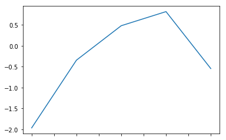

```python
%matplotlib inline
my_series.plot()
```

We can also create a series with automatic index.

```python
pd.Series(data)
```

```
0   -1.966084
1   -0.342964
2    0.482737
3    0.820789
4   -0.544307
dtype: float64
```

Series can be accessed using the same syntax as arrays and dicts. So, we are going to use the labels in the index to access each element.

```python
my_series['b']
```

```
-0.3429641736314189
```

We can also use the label like an attribute:

```python
my_series.b
```

```
-0.3429641736314189
```

Finally, we can specify a range of labels to obtain a slice:

```python
my_series[['b', 'c']]
```

```
b   -0.342964
c    0.482737
dtype: float64
```

Now, let's create a **DataFrame** by passing a numpy array, with a datetime index and labeled columns.

First, the datetime index:

```python
dates = pd.date_range('20130101', periods=6)
dates
```

```
DatetimeIndex(['2013-01-01', '2013-01-02', '2013-01-03', '2013-01-04',
               '2013-01-05', '2013-01-06'],
              dtype='datetime64[ns]', freq='D')
```

Now, we create the DataFrame:

```python
df = pd.DataFrame(np.random.randn(6,4), index=dates, columns=list('ABCD'))
df
```

|  | A | B | C | D |
| --- | --- | --- | --- | --- |
| 2013-01-01 | -0.351566 | 0.012689 | -0.128587 | 1.155873 |
| 2013-01-02 | -0.435586 | -0.306056 | -1.624461 | -0.002928 |
| 2013-01-03 | -1.269034 | 0.237635 | 0.930971 | -0.367027 |
| 2013-01-04 | -0.122854 | -1.170083 | 0.494180 | 1.092589 |
| 2013-01-05 | 1.190880 | 0.026688 | -0.131662 | -0.876023 |
| 2013-01-06 | -0.551989 | -1.622230 | -0.579927 | -1.274028 |

and a second `DataFrame` by passing a dict of objects that can be converted to series-like.

```python
df2 = pd.DataFrame({ 'A' : [1., 2.1, 3.5, 8.1],
                    'B' : pd.Timestamp('20130102'),
                    'C' : pd.Series(1,index=list(range(4)),dtype='float32')})
print(df2)
```

```
     A          B    C
0  1.0 2013-01-02  1.0
1  2.1 2013-01-02  1.0
2  3.5 2013-01-02  1.0
3  8.1 2013-01-02  1.0
```

```python
print(df2.dtypes)
```

```
A           float64
B    datetime64[ns]
C           float32
dtype: object
```

## Viewing Data

You can see the top & bottom rows of the frame:

```python
# 5 top rows
df.head()
```

|  | A | B | C | D |
| --- | --- | --- | --- | --- |
| 2013-01-01 | -0.351566 | 0.012689 | -0.128587 | 1.155873 |
| 2013-01-02 | -0.435586 | -0.306056 | -1.624461 | -0.002928 |
| 2013-01-03 | -1.269034 | 0.237635 | 0.930971 | -0.367027 |
| 2013-01-04 | -0.122854 | -1.170083 | 0.494180 | 1.092589 |
| 2013-01-05 | 1.190880 | 0.026688 | -0.131662 | -0.876023 |

```python
# 3 last rows
df.tail(3)
```

|  | A | B | C | D |
| --- | --- | --- | --- | --- |
| 2013-01-04 | -0.122854 | -1.170083 | 0.494180 | 1.092589 |
| 2013-01-05 | 1.190880 | 0.026688 | -0.131662 | -0.876023 |
| 2013-01-06 | -0.551989 | -1.622230 | -0.579927 | -1.274028 |

Let's display the **index, columns, and the underlying numpy data**:

```python
df.index
```

```
DatetimeIndex(['2013-01-01', '2013-01-02', '2013-01-03', '2013-01-04',
               '2013-01-05', '2013-01-06'],
              dtype='datetime64[ns]', freq='D')
```

```python
df.columns
```

```
Index(['A', 'B', 'C', 'D'], dtype='object')
```

```python
df.values
```

```
array([[-0.3515661 ,  0.01268864, -0.12858744,  1.15587327],
       [-0.43558558, -0.30605563, -1.62446083, -0.00292829],
       [-1.26903436,  0.23763533,  0.93097125, -0.3670272 ],
       [-0.12285441, -1.17008349,  0.49417991,  1.09258912],
       [ 1.19087972,  0.02668763, -0.13166228, -0.87602262],
       [-0.5519893 , -1.62222983, -0.57992687, -1.27402794]])
```

If you are interested in seeing quick statistic summary of your data then:

```python
df.describe()
```

|  | A | B | C | D |
| --- | --- | --- | --- | --- |
| count | 6.000000 | 6.000000 | 6.000000 | 6.000000 |
| mean | -0.256692 | -0.470226 | -0.173248 | -0.045257 |
| std | 0.808260 | 0.751673 | 0.887681 | 1.004269 |
| min | -1.269034 | -1.622230 | -1.624461 | -1.274028 |
| 25% | -0.522888 | -0.954077 | -0.467861 | -0.748774 |
| 50% | -0.393576 | -0.146683 | -0.130125 | -0.184978 |
| 75% | -0.180032 | 0.023188 | 0.338488 | 0.818710 |
| max | 1.190880 | 0.237635 | 0.930971 | 1.155873 |

and if you want to sort your data by a certain column:

```python
df.sort_values(by='B')
```

|  | A | B | C | D |
| --- | --- | --- | --- | --- |
| 2013-01-06 | -0.551989 | -1.622230 | -0.579927 | -1.274028 |
| 2013-01-04 | -0.122854 | -1.170083 | 0.494180 | 1.092589 |
| 2013-01-02 | -0.435586 | -0.306056 | -1.624461 | -0.002928 |
| 2013-01-01 | -0.351566 | 0.012689 | -0.128587 | 1.155873 |
| 2013-01-05 | 1.190880 | 0.026688 | -0.131662 | -0.876023 |
| 2013-01-03 | -1.269034 | 0.237635 | 0.930971 | -0.367027 |

## Selecting data

If you want to select a specific column to print:

```python
print(df['A'])
```

```
2013-01-01   -0.351566
2013-01-02   -0.435586
2013-01-03   -1.269034
2013-01-04   -0.122854
2013-01-05    1.190880
2013-01-06   -0.551989
Freq: D, Name: A, dtype: float64
```

Rows can be selected using either the index:

```python
print(df['20130102':'20130104'])
```

```
                   A         B         C         D
2013-01-02 -0.435586 -0.306056 -1.624461 -0.002928
2013-01-03 -1.269034  0.237635  0.930971 -0.367027
2013-01-04 -0.122854 -1.170083  0.494180  1.092589
```

or simpler using the numeric index of the rows you want to print:

```python
print(df[1:4])
```

```
                   A         B         C         D
2013-01-02 -0.435586 -0.306056 -1.624461 -0.002928
2013-01-03 -1.269034  0.237635  0.930971 -0.367027
2013-01-04 -0.122854 -1.170083  0.494180  1.092589
```

For getting a cross section using a label:

```python
df.loc[dates[0]]
```

```
A   -0.351566
B    0.012689
C   -0.128587
D    1.155873
Name: 2013-01-01 00:00:00, dtype: float64
```

If you want to be even more specific and show only the first two columns of the first three rows:

```python
df.loc['20130101':'20130103',['A','B']]
```

|  | A | B |
| --- | --- | --- |
| 2013-01-01 | -0.351566 | 0.012689 |
| 2013-01-02 | -0.435586 | -0.306056 |
| 2013-01-03 | -1.269034 | 0.237635 |

Sometimes we do not care about the actual value of the index, but only its relevant position. Therefore, if we want to print the values of the fourth date-row:

```python
print(df.iloc[3])
```

```
A   -0.122854
B   -1.170083
C    0.494180
D    1.092589
Name: 2013-01-04 00:00:00, dtype: float64
```

By integer slices, acting similar to numpy/python:

```python
print(df.iloc[3:5,0:2])
```

```
                   A         B
2013-01-04 -0.122854 -1.170083
2013-01-05  1.190880  0.026688
```

Another interesting tool is **the boolean indexing**. We can isolate the rows that meet a specific criterion that we want, such as:

```python
print(df[df.A > 0])
```

```
                  A         B         C         D
2013-01-05  1.19088  0.026688 -0.131662 -0.876023
```

For filtering, the following command helps:

```python
#First, let's create a copy of our dataframe
df2 = df.copy()

# Now, we will add a new column, named "E" with the following values:
df2['E'] = ['one', 'one','two','three','four','three']

#So, now if we want to show the rows that have the value "two" or "four" at the column "E", we will type:
df2[df2['E'].isin(['two','four'])]
```

|  | A | B | C | D | E |
| --- | --- | --- | --- | --- | --- |
| 2013-01-03 | -1.269034 | 0.237635 | 0.930971 | -0.367027 | two |
| 2013-01-05 | 1.190880 | 0.026688 | -0.131662 | -0.876023 | four |

## Operations

One of the essential pieces of NumPy is the ability to perform quick elementwise operations, both with basic arithmetic (addition, subtraction, multiplication, etc.) and with more sophisticated operations (trigonometric functions, exponential and logarithmic functions, etc.). Pandas inherits much of this functionality from NumPy, and the universal functions are key to this.

Pandas includes a couple useful twists, however: for unary operations like negation and trigonometric functions, these universal functions will preserve index and column labels in the output, and for binary operations such as addition and multiplication, Pandas will automatically align indices when passing the objects to the universal function. This means that keeping the context of data, and combining data from different sources – both potentially error-prone tasks with raw NumPy arrays – become essentially foolproof with Pandas. We will additionally see that there are well-defined operations between one-dimensional `Series` structures and two-dimensional `DataFrame` structures.

Because Pandas is designed to work with NumPy, any NumPy universal function will work on pandas Series and DataFrame objects. Lets start by defining a simple Series and DataFrame on which to demonstrate this:

```python
rng = np.random.RandomState(42)
ser = pd.Series(rng.randint(0, 10, 4))
ser
```

```
0    6
1    3
2    7
3    4
dtype: int64
```

```python
df = pd.DataFrame(rng.randint(0, 10, (3, 4)), columns=['A', 'B', 'C', 'D'])
df
```

|  | A | B | C | D |
| --- | --- | --- | --- | --- |
| 0 | 6 | 9 | 2 | 6 |
| 1 | 7 | 4 | 3 | 7 |
| 2 | 7 | 2 | 5 | 4 |

If we apply a NumPy universal function on either of these objects, the result will be another Pandas object with the indices preserved:

```python
np.exp(ser)
```

```
0     403.428793
1      20.085537
2    1096.633158
3      54.598150
dtype: float64
```

Or, for a slightly more complex calculation:

```python
np.sin(df * np.pi / 4)
```

|  | A | B | C | D |
| --- | --- | --- | --- | --- |
| 0 | -1.000000 | 7.071068e-01 | 1.000000 | -1.000000e+00 |
| 1 | -0.707107 | 1.224647e-16 | 0.707107 | -7.071068e-01 |
| 2 | -0.707107 | 1.000000e+00 | -0.707107 | 1.224647e-16 |

For binary operations on two `Series` or `DataFrame` objects, Pandas will align indices in the process of performing the operation. This is very convenient when working with **incomplete data**, as we’ll see in some of the examples below.

As an example, suppose we are combinging two different data sources, and find only the top three US states by area and the top three US states by population:

```python
area = pd.Series({'Alaska': 1723337, 'Texas': 695662,'California': 423967}, name='area')
population = pd.Series({'California': 38332521, 'Texas': 26448193,'New York': 19651127}, name='population')
```

Let’s see what happens when we divide these to compute the population density:

```python
population / area
```

```
Alaska              NaN
California    90.413926
New York            NaN
Texas         38.018740
dtype: float64
```

The resulting array contains the **union** of indices of the two input arrays, which could be determined using standard Python set arithmetic on these indices:

```python
area.index | population.index
```

```
Index(['Alaska', 'California', 'New York', 'Texas'], dtype='object')
```

Any item for which one or the other does not have an entry is marked by NaN, or “Not a Number”, which is how Pandas marks missing data. This index matching is implemented this way for any of Pythons built-in arithmetic expressions; any missing values are filled-in with NaN by default:

```python
A = pd.Series([2, 4, 6], index=[0, 1, 2])
B = pd.Series([1, 3, 5], index=[1, 2, 3])
A + B
```

```
0    NaN
1    5.0
2    9.0
3    NaN
dtype: float64
```

If filling-in NaN values is not the desired behavior, the fill value can be modified using appropriate object methods in place of the operators. For example, calling `A.add(B)` is equivalent to calling A + B, but allows optional explicit specification of the fill value:

```python
A.add(B, fill_value=0)
```

```
0    2.0
1    5.0
2    9.0
3    5.0
dtype: float64
```

A similar type of alingment takes place for both columns and indices when performing operations on dataframes:

```python
A = pd.DataFrame(rng.randint(0, 20, (2, 2)), columns=list('AB'))
A
```

|  | A | B |
| --- | --- | --- |
| 0 | 1 | 11 |
| 1 | 5 | 1 |

```python
B = pd.DataFrame(rng.randint(0, 10, (3, 3)),columns=list('BAC'))
B
```

|  | B | A | C |
| --- | --- | --- | --- |
| 0 | 4 | 0 | 9 |
| 1 | 5 | 8 | 0 |
| 2 | 9 | 2 | 6 |

```python
A+B
```

|  | A | B | C |
| --- | --- | --- | --- |
| 0 | 1.0 | 15.0 | NaN |
| 1 | 13.0 | 6.0 | NaN |
| 2 | NaN | NaN | NaN |

Notice that indices are aligned correctly irrespective of their order in the two objects, and indices in the result are sorted. Similarly to the case of the Series, we can use the associated object’s arithmetic method and pass any desired fill_value to be used in place of missing entries:

```python
A.add(B, fill_value=np.mean(A.values))
```

|  | A | B | C |
| --- | --- | --- | --- |
| 0 | 1.0 | 15.0 | 13.5 |
| 1 | 13.0 | 6.0 | 4.5 |
| 2 | 6.5 | 13.5 | 10.5 |

### Merge, Join, Append

Pandas provides various facilities for easily combining together Series, DataFrame, and Panel objects with various kinds of set logic for the indexes and relational algebra functionality in the case of join / merge-type operations.

```python
df = pd.DataFrame(np.random.randn(10, 4))
df
```

|  | 0 | 1 | 2 | 3 |
| --- | --- | --- | --- | --- |
| 0 | 0.676178 | 1.129256 | -2.014145 | -0.228924 |
| 1 | 0.784652 | 1.081042 | -0.790367 | 1.025078 |
| 2 | 1.315468 | -0.725735 | 0.681284 | 1.026884 |
| 3 | -1.228502 | -0.992752 | -0.356210 | 0.097412 |
| 4 | 1.339647 | -0.820656 | 0.212281 | -0.329965 |
| 5 | 0.218015 | -1.189377 | 0.079336 | 0.350981 |
| 6 | 0.858470 | -0.371466 | -0.441190 | 0.127586 |
| 7 | -0.319459 | -1.495059 | 1.927318 | 0.222475 |
| 8 | 0.429807 | -0.533404 | -1.191769 | -0.177469 |
| 9 | 1.097011 | -0.202964 | 1.260123 | 1.054469 |

```python
# break it into pieces
pieces = [df[:3], df[3:7], df[7:]]
pieces[0]
```

|  | 0 | 1 | 2 | 3 |
| --- | --- | --- | --- | --- |
| 0 | 0.676178 | 1.129256 | -2.014145 | -0.228924 |
| 1 | 0.784652 | 1.081042 | -0.790367 | 1.025078 |
| 2 | 1.315468 | -0.725735 | 0.681284 | 1.026884 |

**`pandas.concat`** command concatenates pandas objects along a particular axis with optional set logic along the other axes.

```python
pd.concat(pieces)
```

|  | 0 | 1 | 2 | 3 |
| --- | --- | --- | --- | --- |
| 0 | 0.676178 | 1.129256 | -2.014145 | -0.228924 |
| 1 | 0.784652 | 1.081042 | -0.790367 | 1.025078 |
| 2 | 1.315468 | -0.725735 | 0.681284 | 1.026884 |
| 3 | -1.228502 | -0.992752 | -0.356210 | 0.097412 |
| 4 | 1.339647 | -0.820656 | 0.212281 | -0.329965 |
| 5 | 0.218015 | -1.189377 | 0.079336 | 0.350981 |
| 6 | 0.858470 | -0.371466 | -0.441190 | 0.127586 |
| 7 | -0.319459 | -1.495059 | 1.927318 | 0.222475 |
| 8 | 0.429807 | -0.533404 | -1.191769 | -0.177469 |
| 9 | 1.097011 | -0.202964 | 1.260123 | 1.054469 |

**`DataFrame.merge`** command merges DataFrame objects by performing a database-style join operation by columns or indexes.

```python
left = pd.DataFrame({'key': ['foo', 'foo'], 'lval': [1, 2]})
right = pd.DataFrame({'key': ['foo', 'foo'], 'rval': [4, 5]})

pd.merge(left, right, on='key')
```

|  | key | lval | rval |
| --- | --- | --- | --- |
| 0 | foo | 1 | 4 |
| 1 | foo | 1 | 5 |
| 2 | foo | 2 | 4 |
| 3 | foo | 2 | 5 |

**`DataFrame.join`** command joins columns with other DataFrame either on index or on a key column. Efficiently Join multiple DataFrame objects by index at once by passing a list.

```python
left.join(right, lsuffix='_caller', rsuffix='_other')
```

|  | key_caller | lval | key_other | rval |
| --- | --- | --- | --- | --- |
| 0 | foo | 1 | foo | 4 |
| 1 | foo | 2 | foo | 5 |

**`DataFrame.append`** command appends rows of other to the end of this frame, returning a new object. Columns not in this frame are added as new columns.

```python
df.append(pieces[0], ignore_index=True)
```

|  | 0 | 1 | 2 | 3 |
| --- | --- | --- | --- | --- |
| 0 | 0.676178 | 1.129256 | -2.014145 | -0.228924 |
| 1 | 0.784652 | 1.081042 | -0.790367 | 1.025078 |
| 2 | 1.315468 | -0.725735 | 0.681284 | 1.026884 |
| 3 | -1.228502 | -0.992752 | -0.356210 | 0.097412 |
| 4 | 1.339647 | -0.820656 | 0.212281 | -0.329965 |
| 5 | 0.218015 | -1.189377 | 0.079336 | 0.350981 |
| 6 | 0.858470 | -0.371466 | -0.441190 | 0.127586 |
| 7 | -0.319459 | -1.495059 | 1.927318 | 0.222475 |
| 8 | 0.429807 | -0.533404 | -1.191769 | -0.177469 |
| 9 | 1.097011 | -0.202964 | 1.260123 | 1.054469 |
| 10 | 0.676178 | 1.129256 | -2.014145 | -0.228924 |
| 11 | 0.784652 | 1.081042 | -0.790367 | 1.025078 |
| 12 | 1.315468 | -0.725735 | 0.681284 | 1.026884 |

### Grouping in Pandas

Most of the time, you have a set of data that lends itself to being categorized or grouped. As a general example, let's say we have data on a wide variety of people. We may perform an analysis where we compare groups in the data based on age, gender, birth month, shoe size, or birth city; the options are as numerous as the data points!

I think it would be intriguing to work now with a proper dataset from Citi Bike - Daily Ridership and Membership Data

```python
df = pd.read_csv('data/201707-citibike-tripdata.csv')
df.head()
```

|  | tripduration | starttime | stoptime | start station id | start station name | start station latitude | start station longitude | end station id | end station name | end station latitude | end station longitude | bikeid | usertype | birth year | gender |
| --- | --- | --- | --- | --- | --- | --- | --- | --- | --- | --- | --- | --- | --- | --- | --- |
| 0 | 364 | 2017-07-01 00:00:00 | 2017-07-01 00:06:05 | 539 | Metropolitan Ave & Bedford Ave | 40.715348 | -73.960241 | 3107 | Bedford Ave & Nassau Ave | 40.723117 | -73.952123 | 14744 | Subscriber | 1986.0 | 1 |
| 1 | 2142 | 2017-07-01 00:00:03 | 2017-07-01 00:35:46 | 293 | Lafayette St & E 8 St | 40.730207 | -73.991026 | 3425 | 2 Ave & E 104 St | 40.789210 | -73.943708 | 19587 | Subscriber | 1981.0 | 1 |
| 2 | 328 | 2017-07-01 00:00:08 | 2017-07-01 00:05:37 | 3242 | Schermerhorn St & Court St | 40.691029 | -73.991834 | 3397 | Court St & Nelson St | 40.676395 | -73.998699 | 27937 | Subscriber | 1984.0 | 2 |
| 3 | 2530 | 2017-07-01 00:00:11 | 2017-07-01 00:42:22 | 2002 | Wythe Ave & Metropolitan Ave | 40.716887 | -73.963198 | 398 | Atlantic Ave & Furman St | 40.691652 | -73.999979 | 26066 | Subscriber | 1985.0 | 1 |
| 4 | 2534 | 2017-07-01 00:00:15 | 2017-07-01 00:42:29 | 2002 | Wythe Ave & Metropolitan Ave | 40.716887 | -73.963198 | 398 | Atlantic Ave & Furman St | 40.691652 | -73.999979 | 29408 | Subscriber | 1982.0 | 2 |

It looks like there is a good opportunity to break the data down into groups to look for some interesting trends. Some ideas are:

- Group on the gender column and see if there are more male or female riders.
- Do specific stations get used more than others? We can group on the station start or finish id.
- Group the data on the day of the week, to see if there is more utilization for a particular day, on average.

### How about a few examples?

If we want to group by just the gender, then we pass this key (column name) to the groupby function as the sole argument. This example is the simplest form of grouping.

```python
groupedGender = df.groupby('gender')
print(groupedGender)
```

```
<pandas.core.groupby.DataFrameGroupBy object at 0x107253d68>
```

The output shows that groupby returns a pandas `DataFrameGroupBy` object. Pandas has just made some internal calculations about the new gender groups and is ready to apply some operation on each of these groups.

Getting back to the data, if we use the `count` method, we can see the total number of entries **for each gender group**. For reference, here's what the website (from where the dataset was downloaded) says for the gender codes - "Gender (Zero=unknown; 1=male; 2=female)"

```python
groupedGender.size()
```

```
gender
0     235194
1    1099384
2     401021
dtype: int64
```

```python
# look at the size as a percentage of the whole (using the trip)
total = df.gender.count()
groupedGender.size() / total * 100
```

```
gender
0    13.551172
1    63.343203
2    23.105625
dtype: float64
```

It looks like males make up the majority of Citi Bike riders (~63%)!

We can use a single column from the `DataFrameGroupBy` object and apply some aggregation function on it - how about the **mean** and **standard deviation** of the trip durations for all three groups?

```python
groupedGender['tripduration'].mean() / 60.
```

```
gender
0    31.229350
1    15.028095
2    16.956202
Name: tripduration, dtype: float64
```

```python
# Don't have to use the bracket notation
groupedGender.tripduration.std() / 60.
```

```
gender
0    223.804023
1    147.871659
2    147.872049
Name: tripduration, dtype: float64
```

Although males make up the majority of Citi Bike riders, there's not much of a difference in their trip durations. Interestingly, gender unknown riders take 2x as long of rides on average. These riders are likely single-use customers (when you purchase a one time pass at a Citi Bike kiosk you are not asked for your gender).

So there are some summary statistics for these groups (as an aside, you can use the describe function to get these statistics and more in one call). That's a whole lot of spread around the mean, which probably means there are some outliers in the data (maybe people that kept the bike for days). Just a brief look at this even though it's outside the scope, because I'm sure you were all interested 😊

```python
df[df.tripduration > 10000].tripduration.count()
5110
```

```
5110
```

Our suspicions are confirmed - there are many bike rentals outside 2:45 even though the "max" is supposed to be 30 minutes (or 45 if you're a Citi Bike member).

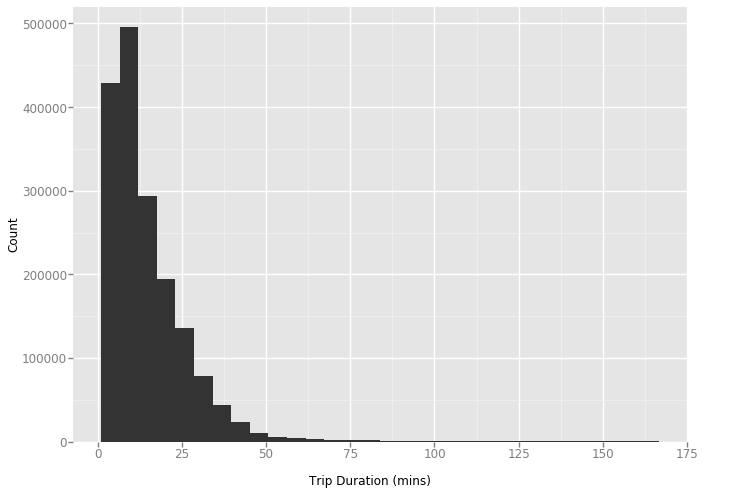

```python
from ggplot import *

df_short = df[df.tripduration < 10000]
df_short.tripduration = df_short.tripduration / 60.
ggplot(df_short, aes(x='tripduration')) + geom_histogram(bins=30) + xlab("Trip Duration (mins)") + ylab("Count")
```

One last example is looking at which are the five favorite start and end stations. We'll group the data based on the start and end station names, apply the count function, and sort the values is descending order.

```python
groupedStart = df.groupby('start station name')
groupedStart['start station name'].count().sort_values(ascending=False)[:5]
```

```
start station name
Pershing Square North    14853
West St & Chambers St    14118
12 Ave & W 40 St         12263
E 17 St & Broadway       11124
W 20 St & 11 Ave         10652
Name: start station name, dtype: int64
```

```python
groupedEnd = df.groupby('end station name')
groupedEnd['end station name'].count().sort_values(ascending=False)[:5]
```

```
end station name
West St & Chambers St    14795
Pershing Square North    14469
12 Ave & W 40 St         12690
E 17 St & Broadway       11429
W 20 St & 11 Ave         11145
Name: end station name, dtype: int64
```

One last thing! Whenever we have a time-series dataset it is very useful to assign the time as index for our dataframe. Let's do that with the method **`set_index()`** of the DataFrame object.

```python
df=df.set_index('starttime')
df.head()
```

| starttime | tripduration | stoptime | start station id | start station name | start station latitude | start station longitude | end station id | end station name | end station latitude | end station longitude | bikeid | usertype | birth year | gender |
| --- | --- | --- | --- | --- | --- | --- | --- | --- | --- | --- | --- | --- | --- | --- |
| 2017-07-01 00:00:00 | 364 | 2017-07-01 00:06:05 | 539 | Metropolitan Ave & Bedford Ave | 40.715348 | -73.960241 | 3107 | Bedford Ave & Nassau Ave | 40.723117 | -73.952123 | 14744 | Subscriber | 1986.0 | 1 |
| 2017-07-01 00:00:03 | 2142 | 2017-07-01 00:35:46 | 293 | Lafayette St & E 8 St | 40.730207 | -73.991026 | 3425 | 2 Ave & E 104 St | 40.789210 | -73.943708 | 19587 | Subscriber | 1981.0 | 1 |
| 2017-07-01 00:00:08 | 328 | 2017-07-01 00:05:37 | 3242 | Schermerhorn St & Court St | 40.691029 | -73.991834 | 3397 | Court St & Nelson St | 40.676395 | -73.998699 | 27937 | Subscriber | 1984.0 | 2 |
| 2017-07-01 00:00:11 | 2530 | 2017-07-01 00:42:22 | 2002 | Wythe Ave & Metropolitan Ave | 40.716887 | -73.963198 | 398 | Atlantic Ave & Furman St | 40.691652 | -73.999979 | 26066 | Subscriber | 1985.0 | 1 |
| 2017-07-01 00:00:15 | 2534 | 2017-07-01 00:42:29 | 2002 | Wythe Ave & Metropolitan Ave | 40.716887 | -73.963198 | 398 | Atlantic Ave & Furman St | 40.691652 | -73.999979 | 29408 | Subscriber | 1982.0 | 2 |

You have already seen today how we could identify demand patterns using the timestamps that the dataset offers. Next time, we will be able to see more using the Python Pandas module.

## 2. Exercises

Let's explore in more depth the possibilities providaded by the Python Pandas module. To make things less confusing, we decided to use the same dataset as in the numpy exercise. In fact, you'll start with doing exactly the **same** exercises. Then, an incremental set of exercises end up with ... !!!

So, let's start. Since we are going to work with Pandas, let's just import it, shall we (you'll eventually also need Numpy, so import that too)?

```python
import pandas as pd
import numpy as np
```

We need some data. Please open the file "pickups_zone_1_15min.csv". This corresponds to the series of taxi-pickups in New York zone 1 (an area in the Manhattan island).

You can use the method read_csv(file), which **returns** a DataFrame:

> df=pd.read_csv(file)

df is a variable that now has a Pandas DataFrame

```python
df=pd.read_csv("data/pickups_zone_1_15min.csv")
```

Good, so we just loaded the file, now let's look at its content (and keep remembering how more complicated it was in Numpy).

```python
df.head()
```

|  | date | hour | minute | pickups |
| --- | --- | --- | --- | --- |
| 0 | 2009-01-01 | 0 | 0 | 0 |
| 1 | 2009-01-01 | 0 | 15 | 166 |
| 2 | 2009-01-01 | 0 | 30 | 215 |
| 3 | 2009-01-01 | 0 | 45 | 223 |
| 4 | 2009-01-01 | 1 | 0 | 245 |

Just to be sure, let's check how many lines the file actually has (now it should be 262848, one line less, why?).

```python
len(df)
```

```
262848
```

Print the first 10 lines of this file.

```python
df[:10]
```

|  | date | hour | minute | pickups |
| --- | --- | --- | --- | --- |
| 0 | 2009-01-01 | 0 | 0 | 0 |
| 1 | 2009-01-01 | 0 | 15 | 166 |
| 2 | 2009-01-01 | 0 | 30 | 215 |
| 3 | 2009-01-01 | 0 | 45 | 223 |
| 4 | 2009-01-01 | 1 | 0 | 245 |
| 5 | 2009-01-01 | 1 | 15 | 182 |
| 6 | 2009-01-01 | 1 | 30 | 181 |
| 7 | 2009-01-01 | 1 | 45 | 190 |
| 8 | 2009-01-01 | 2 | 0 | 197 |
| 9 | 2009-01-01 | 2 | 15 | 212 |

Oh, remember that we need to make a single field with the datetime (instead of 3 separate ones...)!

Pandas actually allows us to simplify that right when we load the file. So, let's do it again, but now take a look at the following Stackexchange thread: https://stackoverflow.com/questions/38509512/pandas-read-csv-with-date-in-2-columns

How about applying this here?

```python
df = pd.read_csv("data/pickups_zone_1_15min.csv", sep=',', parse_dates={'dt': [0, 1, 2]})
df.head()
```

|  | dt | pickups |
| --- | --- | --- |
| 0 | 2009-01-01 0 0 | 0 |
| 1 | 2009-01-01 0 15 | 166 |
| 2 | 2009-01-01 0 30 | 215 |
| 3 | 2009-01-01 0 45 | 223 |
| 4 | 2009-01-01 1 0 | 245 |

It may happen that the (new) temporal field is still a string and not a datetime object. Can you correct that?

```python
import datetime

df['datetime']=df['dt'].apply(lambda x: datetime.datetime.strptime(x, "%Y-%m-%d %H %M"))

del df['dt']
df.head()
```

|  | pickups | datetime |
| --- | --- | --- |
| 0 | 0 | 2009-01-01 00:00:00 |
| 1 | 166 | 2009-01-01 00:15:00 |
| 2 | 215 | 2009-01-01 00:30:00 |
| 3 | 223 | 2009-01-01 00:45:00 |
| 4 | 245 | 2009-01-01 01:00:00 |

In fact, it can be useful to assign the time as index for our dataframe. Let's do that with the method set_index() of the DataFrame object. Notice that it doesn't do "in-place" changes, in other words, this command would not work:

> df.set_index(KEY)

You'd have to do

> df=df.set_index(KEY)

```python
df=df.set_index('datetime')
df.head()
```

| datetime | pickups |
| --- | --- |
| 2009-01-01 00:00:00 | 0 |
| 2009-01-01 00:15:00 | 166 |
| 2009-01-01 00:30:00 | 215 |
| 2009-01-01 00:45:00 | 223 |
| 2009-01-01 01:00:00 | 245 |

Important note: You can always get a vector with the indeces themselves with

> df.index

To understand this, just try it yourself

So, just for fun (and to compare with the amount of work we did with Numpy), let's get **only** the pickups part.

```python
df['pickups'][:10]
```

```
datetime
2009-01-01 00:00:00      0
2009-01-01 00:15:00    166
2009-01-01 00:30:00    215
2009-01-01 00:45:00    223
2009-01-01 01:00:00    245
2009-01-01 01:15:00    182
2009-01-01 01:30:00    181
2009-01-01 01:45:00    190
2009-01-01 02:00:00    197
2009-01-01 02:15:00    212
Name: pickups, dtype: int64
```

Trivial, isn't it? It's even indexed correctly! :-)

Now, it's time for our histogram for the pickups. If you can't remember or don't know how it's done, feel free to search online (something like "Pandas histogram")

again, don't forget to add

> import matplotlib.pyplot as plt

> %matplotlib inline

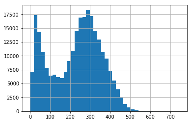

```python
import matplotlib.pyplot as plt
%matplotlib inline

df['pickups'].hist(bins=40);
```

It's even scary how easy it is, right?

What about the scatter plot? It won't be as direct, you will have to use the pyplot one (the one you used last time)

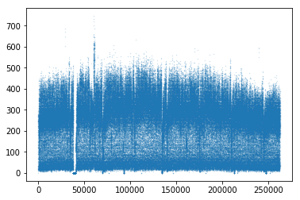

```python
plt.scatter(range(len(df['pickups'])), df['pickups'], s=0.1, alpha=0.3);
```

Now let's do that version with the colors. As last time, you need to create a new vector with the minutes since midnight.

```python
vminute_of_day=np.array([d.hour*60+d.minute for d in df.index])
vminute_of_day[:10]
```

```
array([  0,  15,  30,  45,  60,  75,  90, 105, 120, 135])
```

Even though it may sound redundant, it may be useful to add this new series to the DataFrame (as a new column, in practice).

```python
df['minute_of_day']=vminute_of_day
```

So, let's do the graph with the colors.

Remember, imagine that the number of minutes since midnight (that you just created) corresponds to a color. The function scatter allows you to give this list straight away and plot it (just use the argument c, for example "c=my_minute_since_midnight_list".

Do you want to try?

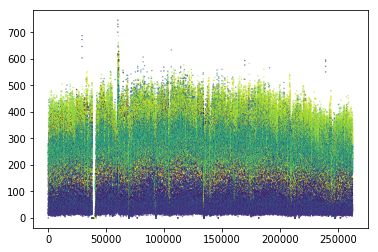

```python
plt.scatter(range(len(df['pickups'])), df['pickups'], s=0.1, c=vminute_of_day);
```

Now, for the 24-hr average plot, where the x axis is 0 to 1440 (1440=24 hours X 60 minutes), and you show the average per minute.

(don't forget to add the 5 and 95 quantiles)

A small tip (mean of 15 minutes of the day):

> df.loc[df['minute_of_day']==15].mean()

> Output:

pickups 205.344047

minute_of_day 15.000000

dtype: float64

**IMPORTANT:** notice that the output above is not just the mean of the *pickups* (which is what we want). It also returns the mean of the minute_of_day itself (which is obviously 15!)... This may confuse things later on, so how do you get the mean of pickups only?

```python
TIME_RESOLUTION=15
day_ts=np.arange(0,1440, TIME_RESOLUTION)

average_line=[df.loc[df['minute_of_day']==tt]['pickups'].mean() for tt in day_ts]
q5_line=[df.loc[df['minute_of_day']==tt]['pickups'].quantile(.05)  for tt in day_ts]
q95_line=[df.loc[df['minute_of_day']==tt]['pickups'].quantile(.95) for tt in day_ts]
```

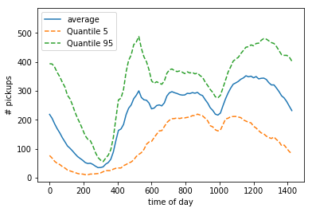

```python
plt.plot(day_ts,average_line, label="average")
plt.plot(day_ts,q5_line, "--", label="Quantile 5")
plt.plot(day_ts,q95_line, "--", label="Quantile 95")
plt.ylim(ymax=np.max(q95_line)*1.2)
plt.legend()
plt.xlabel("time of day")
plt.ylabel("# pickups")
plt.show()
```

### Correlations

*For this part, we'll keep the text as is. The exercises are exactly the same.*

One very important task in Data Science modeling is to find (and understand) correlations between different variables. Let's do a few simple exercises.

Let's start with a simple question: are the different areas correlated between them? If yes, it may be interesting knowledge. For example, maybe we can share data between them to predict better, later.

Tip: Try to make a single DataFrame with ALL time series (s1, s17, s21, s28).

```python
def my_read_csv(file):
    df = pd.read_csv(file, sep=',', parse_dates={'dt': [0, 1, 2]})
    df['datetime']=df['dt'].apply(lambda x: datetime.datetime.strptime(x, "%Y-%m-%d %H %M"))
    del df['dt']
    return df.set_index('datetime')
```

```python
s1=my_read_csv("data/pickups_zone_1_15min.csv")
s17=my_read_csv("data/pickups_zone_17_15min.csv")

smerge=s1.join(s17, rsuffix="17")
smerge['pickups1']=smerge['pickups']
del smerge['pickups']
smerge.head()
```

| datetime | pickups17 | pickups1 |
| --- | --- | --- |
| 2009-01-01 00:00:00 | 339 | 0 |
| 2009-01-01 00:15:00 | 285 | 166 |
| 2009-01-01 00:30:00 | 214 | 215 |
| 2009-01-01 00:45:00 | 202 | 223 |
| 2009-01-01 01:00:00 | 198 | 245 |

```python
smerge.corr()
```

|  | pickups17 | pickups1 |
| --- | --- | --- |
| pickups17 | 1.000000 | 0.881971 |
| pickups1 | 0.881971 | 1.000000 |

Now, a more interesting question: are there correlations between a given area, and the other areas in earlier time steps?

This is a VERY important one. If you find high correlation, for example, between area 1 at time t, with area 17 at time t-1, then you can use area 17 to predict area 1!

To check this, you need to play a little bit with the vectors. Let's call a vector that is shifted in time for 1 time step, a "lag1" vector.

The process is similar to Numpy's, but there's a few tweaks. To make things simpler, we copy a solution from Stackoverflow:

```python
def buildLaggedFeatures(s, columns, lag=1, dropna=True):
    '''
    From http://stackoverflow.com/questions/20410312/how-to-create-a-lagged-data-structure-using-pandas-dataframe
    Builds a new DataFrame to facilitate regressing over all possible lagged features
    '''
    if type(s) is pd.DataFrame:
        new_dict={}
        for c in s.columns:
            new_dict[c]=s[c]
        for col_name in columns:
            new_dict[col_name]=s[col_name]
            # create lagged Series
            for l in range(1,lag+1):
                new_dict['%s_lag%d' %(col_name,l)]=s[col_name].shift(l)
        res=pd.DataFrame(new_dict,index=s.index)

    elif type(s) is pd.Series:
        the_range=range(lag+1)
        res=pd.concat([s.shift(i) for i in the_range],axis=1)
        res.columns=['lag_%d' %i for i in the_range]
    else:
        print('Only works for DataFrame or Series')
        return None
    if dropna:
        return res.dropna()
    else:
        return res
```

```python
smerged_lagged_s1=buildLaggedFeatures(smerge, ['pickups1', 'pickups17'])
```

Let's now check those correlations

```python
smerged_lagged_s1.corr()
```

|  | pickups1 | pickups17 | pickups17_lag1 | pickups1_lag1 |
| --- | --- | --- | --- | --- |
| pickups1 | 1.000000 | 0.881973 | 0.856308 | 0.976703 |
| pickups17 | 0.881973 | 1.000000 | 0.982116 | 0.894895 |
| pickups17_lag1 | 0.856308 | 0.982116 | 1.000000 | 0.881971 |
| pickups1_lag1 | 0.976703 | 0.894895 | 0.881971 | 1.000000 |

WOW! Very interesting!! This means that you can use data from these other areas to predict for area 1... This is useful when there is missing data in area 1, for example...

Now, let's get to the autocorrelogram. Well, in Pandas, this is trivial!

You can use the auto_corr method:

> s1=df['pickups'] #s1 is now a Series

> print(s1.autocorr(1)) #gives the autocorrelation of lag 1

Output:

0.97670270955196936

Cool, now you just need to get values for the different lags (1, 2, 3, 4...) and plot the values!

```python
s1=df['pickups']
autocors=[s1.autocorr(lag) for lag in range(1, 120)]
```

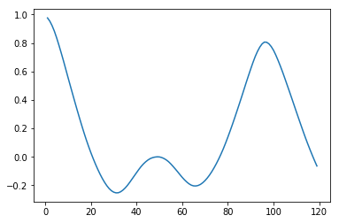

```python
plt.plot(range(1,120), autocors)
plt.show()
```